# Untitled

Robert Day

Royal Perth Hospital

Tegan Rourke

Sir Charles Gaidner Hospital

Hilary

The Conference Company

7/11/2019

# prologue

In 2013 EPSM came to Perth, and for various reasons members of the WA branch organised the abstract submissions, scheduling and production of the abstract book. Just like the old days. This gave us direct access to the submission data, so like good scientists we looked at the time series. What we saw was that people

1. left their submission to the very last minute
2. definitely expected a deadline extension
3. still left their extended submission to the very last minute

Has anything changed since then?

# modus

Just as all happy families are the same, so all happy data analyses are alike. They all follow a common pattern[^1]:

- munge
- analyse
- present

## raw data

The submission data from http://theconferencecompany.com were in an Excel™ workbook with several sheets, formatted to their requirements. These were saved as individual `.csv` files, named for the sheet name. The first sheet had details of the EPSM 2019 abstracts, without dates but labelled in submission order. This contained columns for the submitter, title etc. which were not saved to `EPSM2019_subs.csv` to maintain submitter privacy.

A second sheet listed the number of submissions recieved each day for the EPSM meetings in Hobart 2017, Adelaide 2018 and Perth 2019. Dates were given as days prior to the conference opening date, in order to be able to compare conferences with different dates across years. The columns for date and submissions each day were saved as `Registration.csv` file, as was the complete sheet of abstract details. Submissions from EPSM 2013 were already in a `.csv` file using calendar dates. These were converted to days prior to allow comparison.

EPSM and AOCMP abstracts were not seperated in the spreadsheet, so a list of ID numbers for AOCMP abstracts supplied separately by email was used to classify the abstracts. This list was saved as a single column `AOCMP_abstracts.csv` file.

Finally, significant dates for each conference were gathered from emails and previous conference websites, making use of http://www.archive.org as needed, and saved in `conf.dates.csv`.

see `clean_2019.Rmd` for details.

1. load submission day files
2. clean
3. save to data_clean

## Compare periods

Read the significant dates and convert them all to days-before-conference, then rearrange to long format for easier plotting.

```r
events <- fread(file.path(raw_path, "conf.dates.csv"))
# Make a conference column that matches the other tables
events[, conference := paste(city, year, sep = "_")]
# add the file names
events[, filename := file.path(clean_path, paste0(conference, ".csv"))]

# The same information, converted to day prior to conference
event_days <- events[, lapply(.SD,
                              function(x) as.integer(difftime(x, date))
                              ),
                     .SDcols = c("call", "close", "extended"),
                     by="conference,year,city"]
# Add a key to make indexing faster and easier
setkey(event_days, conference)

# Calculate how long each period was
period <- event_days[, .(total    = call,
                         initial  = call-close,
                         extended = close-extended,
                         waiting  = extended),
                     by="conference,year,city"]

# Make conference an ordered factor so ggplot doesn't rearrange
period[, conference := factor(conference, period[order(year), ]$conference)]
# Convert to long for for plotting
period_long <- melt(period,
                    measure.vars = c("initial", "extended", "waiting"),
                    variable.name = "period",
                    value.name = "days"
                   )
# Add a key to make indexing faster and easier
setkey(period_long, conference)
```

Finally, load the submission days for all the conferences into a unified format, in order of submission. Then generate the cumulative sum of submissions.

```r
SUBS <- events[, fread(filename, col.names = c("day", "n"))[order(day), ], by=conference]
# Add a key to make indexing faster and easier
setkey(SUBS, conference)
# Calcuate the total number of submissions up to each day
SUBS[, sum := cumsum(n[order(day)]), by=conference]
# Make a meeting column as a factor with the order we define
SUBS[, meeting := factor(conference, levels= events[order(year), conference]) ]
```

Classify the submissions into

- premature – before call for papers
- early – before the close
- lucky – after the first close but before the extention period ends
- late – after the extended period closes (won’t be any of those, right?)

```r
SUBS[day < event_days[conference, close], status := 'early', by=conference]
SUBS[day < event_days[conference, call], status := 'premature', by=conference]
SUBS[day > event_days[conference, extended], status := 'late', by=conference]
# The only un-lablled statuses must be the lucky ones
SUBS[is.na(status), status := "lucky"]
# Make the status a factor and put in temporal order
SUBS[, status := factor(status, levels = c("premature", "early", "lucky", "late"))]
```

# analyse this

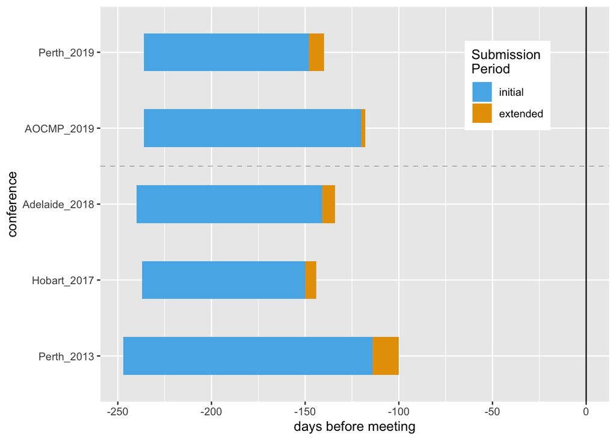

Time allowed for submissions by conference

```r
# Use a colourblind friendly palette with grey
ggplot(period_long) +
  aes(x = conference, y = days, fill = period) +
  geom_col(width = 0.5) +
  scale_fill_manual(name = "Submission\nPeriod",
                    breaks = c("initial", "extended"),
                    values=c("#56B4E9", "#E69F00", NA)) +
  geom_hline(yintercept = 0, colour = "black") +
  geom_vline(xintercept = 3.5, linetype = 2, size = 0.1) +
  ylab("days before meeting") +
  theme(legend.position=c(.80, .8)) +
  coord_flip()
```

EPSM conferences vary slightly in the length of time they allow for submitting abstracts, although they all call for papers about 240 days before the conference. EPSM 2013 in Perth looks like an outlier, starting earlier and running longer, with an extension period about twice that of other conferences. These meant that there was less time between the last submisison and the conference starting.

```
##    year     city total initial extended waiting
## 1: 2019    Perth   236      88        8     140
## 2: 2018 Adelaide   240      99        7     134
## 3: 2017   Hobart   237      87        6     144
## 4: 2013    Perth   247     133       14     100
```

There were plenty of papers at each conference.

```r
# How many papers in each status group, by conference
tbl <- dcast(SUBS, value.var = "n", conference~status, fun = sum)
# and add the sum of all papers, per conference
tbl[, total:=base::sum(.SD), by=conference]
# make in year order
tbl <- tbl[order(-str_extract(conference, "_(.*)")),]
print(tbl[, total, by=conference])
```

```
##       conference total
## 1:    AOCMP_2019   117
## 2:    Perth_2019   217
## 3: Adelaide_2018   231
## 4:   Hobart_2017   170
## 5:    Perth_2013   219
```

Perth 2019 is a monster with the assistance of AOCMP, weighing in at 334 papers in total.

Hobart in 2017 looks a bit light on, but this may be due to some late submissions being missed[^2].

How many in each group?

```r
print(tbl)
```

```
##       conference early lucky late total
## 1:    AOCMP_2019    78    39    0   117
## 2:    Perth_2019    88    99   30   217
## 3: Adelaide_2018    70   130   31   231
## 4:   Hobart_2017    26    90   54   170
## 5:    Perth_2013    44   154   21   219
```

As the absolute numbers are quite different it might be more useful to look at the percentage of papers in each group.

```r
tbl_percent <- tbl[, lapply(.SD, function(x) round(100 * x / total, 1)), by=conference]
print(tbl_percent[, -"total"])
```

```
##       conference early lucky late
## 1:    AOCMP_2019  66.7  33.3  0.0
## 2:    Perth_2019  40.6  45.6 13.8
## 3: Adelaide_2018  30.3  56.3 13.4
## 4:   Hobart_2017  15.3  52.9 31.8
## 5:    Perth_2013  20.1  70.3  9.6
```

The AOCMP authors appear to be good at keeping to deadlines, with 2/3 of submissions in before the advertised close, and no late submissions. By contrast EPSM authors like to live dangerously, with 56.3% of submissions in the extension period on average.

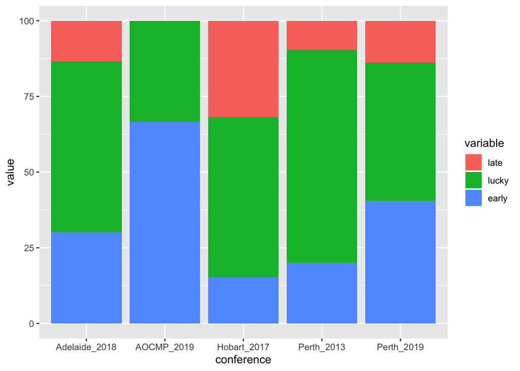

```r
tbl_long <- melt(tbl_percent[, -"total"], id.vars = "conference")
tbl_long[, variable := factor(variable, levels = c("late", "lucky", "early"))]
ggplot(tbl_long) +
         aes(x=conference, y = value, fill = variable) +
         geom_col()
```

# what themes abounded?

Load the submission details for the two Perth meetings, as we have no others.

```r
details <- data.table(file = dir(path = clean_path,
                                 pattern = "details.csv",
                                 full.names = TRUE)
)
details[, year := str_match(file, "\\_(\\d{4})\\_")[,2]]
PER <- details[, fread(file), by=year]
```

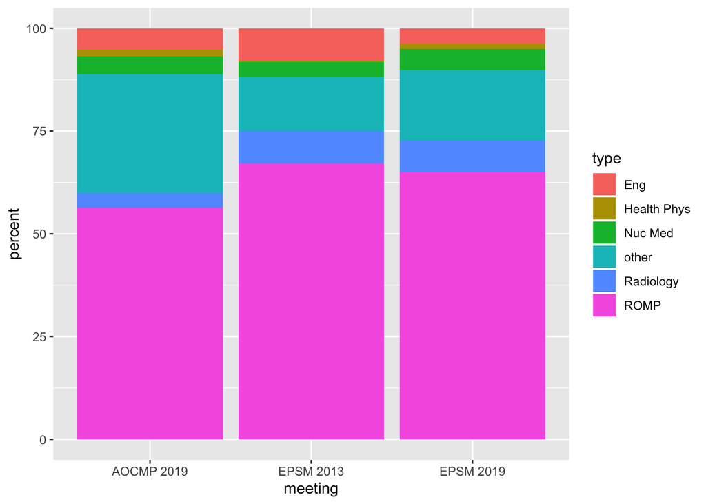

```r
# # Add a year marker to so can differentiate when merged
# PER_13[, year := 2013]
# PER_19[, year := 2019]
# # Merge with the common set of columns
# common_cols <- c("submitter", "city", "state","country", "theme", "ID", "conference", "year")
# PER <- rbind(PER_13[, ..common_cols], PER_19[, ..common_cols])
# Make some broad classes of submission, based on which theme was chosen
PER[theme %like% "Radiology", type := "Radiology"]
PER[theme %like% "ROMP|Radiotherapy", type := "ROMP"]
PER[theme %like% "Nuclear Med", type := "Nuc Med"]
PER[theme %like% "Health Phys", type := "Health Phys"]
PER[theme %like% "Engineer", type := "Eng"]
# A catch-all for the rest
PER[is.na(type), type := "other"]
# Two conferences in Perth this year, so label by meeting to tell them apart
PER[, meeting := paste(conference, year)]

# Calculate percentages by first getting the total count per meeting
# then dividing the count per type by that total
# numbers <- PER[, {
#                   total = .N
#                   .SD[,.(percent = 100*(.N/total)), by = type]
#                  }, by = meeting
#               ]
numbers <- PER[, .N, by = "type,meeting"][, .(type, percent = 100*(N/sum(N))), by=meeting]
ggplot(numbers)+aes(x = meeting, y = percent, fill = type) + geom_col()
```

The percentage of abstracts in each discipline seem fairly stable over time, although EPSM 2013 had a higher proportion of ROMP and Engineering related content and less Nuclear Medcine or Health Physics. EPSM 2013 may have had more Engineering abstracts because the Engineers on the conference committee were actively rounding up submissions.

```r
print(dcast(numbers, type~meeting)[, lapply(.SD, round, 2), by = type])
```

```
##           type AOCMP 2019 EPSM 2013 EPSM 2019
## 1:         Eng       5.13      7.76      3.69
## 2: Health Phys       1.71      0.46      1.38
## 3:     Nuc Med       4.27      3.65      5.07
## 4:        ROMP      56.41     67.12     64.98
## 5:   Radiology       3.42      7.76      7.83
## 6:       other      29.06     13.24     17.05
```

AOCMP members seem less interested in Radiology Physics, with a lot more ‘other’ abstracts. This may be at least in part to the wide range of available themes in 2019.

No-one seems to love Health Physics, which is sad.

# sharing the blame

[^1]: Expressed most clearly by the Underpants Gnomes  
    1. collect underpants  
    2. ???  
    3. profit!
[^2]: Rourke, T. 2019 Personal communication.